# Biomarkers of Recent Cannabis Use

Yutong Guo, Tengyue Wang, Shivani Suthar

## Introduction

In this project, we aim to address this pitfall in current cannabis driving laws by analyzing data from a study that assessed how recent cannabis smoking influences cannabis user’s performances on a driving simulator test (Hubbard et al., 2021). More specifically, in this study, self-reported cannabis smokers were categorized as “frequent” (those who smoke 4 times or more a week) and “infrequent” (those who smoke less than 4 times a week) and during the experiment, were given either a “placebo” (0.02%), “low-dose” (containing 5.90% THC), or “high-dose”(containing 13.40% THC) joint to smoke. After smoking, over the next 6 hours, the participants were periodically given a driving simulator test to test impairment levels and samples of their blood, oral fluid, and breath tests were also taken to measure levels of certain compounds including THC and THC metabolites. Before the experiment, participants were trained on the driving simulator test and were asked to refrain from smoking 2 days prior to the experiment (this was tested by seeing if their oral fluid THC concentration were 5 ng/mL or above on day of study and if it was, they weren’t included in the experiment) to ensure that all participants were at the same baseline for their driving simulator test skills and THC levels before the experiment began. More specifically, in this project, we will be analyzing the data obtained from the blood, oral fluid, and breath tests from this study in order to determine the best biomarker indicative of recent cannabis use.

Overall, the primary motivation behind our project is to help inform driving laws regarding cannabis so that 1) everyone is safe on the road and 2) people are not wrongly incriminated at roadside for endangering others even if they are not actually impaired. Furthermore, we would like to extend this investigation by looking into the co-occurrence of cannabis use with other hard drugs because understanding these patterns is crucial for informing comprehensive policies on impaired driving. This is because when stopped at the roadside, it could be beneficial for officers to know the likelihood that the driver may have used other hard drugs to make further drug testing more efficient and targeted. By understanding the co-occurrence of cannabis use with other hard drugs, law enforcement can better prioritize testing procedures, ensuring a more focused approach in identifying potential substance-related impairments. This not only enhances the efficiency of roadside testing but also contributes to more informed decision-making regarding the necessity for comprehensive drug assessments. By answering the question - How does the frequency of cannabis use correlate with the use of other hard drugs for people of ages 15-64 (as these are typical driving ages)? - we aim to provide a broader context for our primary investigation into recent cannabis use’s impact on driving performance.

## Questions

As discussed above, the primary question we aim to address in this project is 1) Which compound, in which matrix, and at what cutoff is the best biomarker of recent use?

In this question, “compound” refers to the chemical compounds in ones blood, “matrix” refers to the 3 data tables we will be working with - blood, oral fluid, and breath, and “cutoff” refers to the level of the compound a driver can have in them.

Answering this question will help to inform driving laws regarding cannabis because it would 1) help determine which testing method officers should use at roadside (blood test, oral fluid, or breath test), 2) help determine what compound is the most important to look for, and 3) help determine the level of that compound one can have in their body that would indicate that they smoked recently and are actually impaired.

As discussed above, the secondary question we aim to address in this project is 2) How does the frequency of cannabis use correlate with the use of other hard drugs for people of ages 15-64?

## The Data

As mentioned, the data we will be working with in this project include data obtained from the blood, oral fluid, and breath tests of the study mentioned. Below, we will complete some pre-processing of the data so that it is easy to work with and then, we will display the data and explain its components.

### Load packages

Here, we are loading necessary R packages required to work with our data

```r
library(tidyverse)
library(tidymodels)
library(dplyr)
library(forcats)
library(tidyr)
library(ggplot2)
library(pROC)
```

### Data Import

Here, we are importing the data

Please note: Here, “WB” stands for whole blood and is where the blood collection data will be stored. “BR” stands for breath and is where the breath test data will be stored. “OF” stands for oral fluid and is where the the oral fluid data will be stored

```r
WB <- read_csv("data/Blood.csv")
BR <- read_csv("data/Breath.csv")
OF <- read_csv("data/OF.csv")
```

### Data Wrangling

Here, we are wrangling the data following the instructions in class to ensure consistency and clarity in the representation of treatment groups and user categories across multiple data sets. This involves recoding the levels of categorical variables such as treatment dosages and user frequency in OF, WB, and BR data frames. Specifically, the treatment percentages are standardized to a uniform format, and user groups are relabeled to more accurately reflect their experience levels. Additionally, the fct_relevel function is used to reorder treatment levels for analytic convenience. The janitor::clean_names() function standardizes column names for uniformity, and the rename function is employed to make specific variable names more intuitive and consistent across the data sets, facilitating easier comparison and analysis.

```r
OF <- OF |>
  mutate(treatment = fct_recode(Treatment,
                                "5.9% THC (low dose)" = "5.90%",
                                "13.4% THC (high dose)" = "13.40%"),
         Treatment = fct_relevel(Treatment, "Placebo", "5.9% THC (low dose)"),
         Group = fct_recode(Group,
                            "Occasional user" = "Not experienced user",
                            "Frequent user" = "Experienced user" )) |>
  janitor::clean_names() |>
  rename(thcoh = x11_oh_thc,
         thcv = thc_v)

WB <- WB |>
  mutate(Treatment = fct_recode(Treatment,
                                "5.9% THC (low dose)" = "5.90%",
                                "13.4% THC (high dose)" = "13.40%"),
         Treatment = fct_relevel(Treatment, "Placebo", "5.9% THC (low dose)")) |>
  janitor::clean_names() |>
  rename(thcoh = x11_oh_thc,
         thccooh = thc_cooh,
         thccooh_gluc = thc_cooh_gluc,
         thcv = thc_v)

BR <- BR |>
  mutate(Treatment = fct_recode(Treatment,
                                "5.9% THC (low dose)" = "5.90%",
                                "13.4% THC (high dose)" = "13.40%"),
         Treatment = fct_relevel(Treatment, "Placebo", "5.9% THC (low dose)"),
         Group = fct_recode(Group,
                            "Occasional user" = "Not experienced user",
                            "Frequent user" = "Experienced user" )) |>
  janitor::clean_names() |>
  rename(thc = thc_pg_pad)
```

### Data Display and Explanation

Now that we are done pre-processing the data, we will display what each of the 3 data tables (blood, oral fluid, and breath) look like below:

Blood data table:

```r
WB
```

```
## # A tibble: 1,525 × 14
##    id    treatment   group  fluid_type timepoint   cbn   cbd   thc thcoh thccooh
##    <chr> <fct>       <chr>  <chr>      <chr>     <dbl> <dbl> <dbl> <dbl>   <dbl>
##  1 11255 5.9% THC (… Occas… WB         T1          0       0   0.5   0       5.7
##  2 11255 5.9% THC (… Occas… WB         T2A         2.8     0  32.4   5.4    13.5
##  3 11255 5.9% THC (… Occas… WB         T2B         0.6     0   5.1   2.4    11.7
##  4 11255 5.9% THC (… Occas… WB         T3A         0       0   3.2   1.8     9.7
##  5 11255 5.9% THC (… Occas… WB         T3B         0       0   1.8   1.4     8.7
##  6 11255 5.9% THC (… Occas… WB         T4A         0       0   1.2   0       6.7
##  7 11255 5.9% THC (… Occas… WB         T4B         0       0   0.9   0       6.8
##  8 11255 5.9% THC (… Occas… WB         T5A         0       0   0.8   0       6.8
##  9 11255 5.9% THC (… Occas… WB         T5B         0       0   0.6   0       6.3
## 10 T0686 5.9% THC (… Frequ… WB         T1          0       0   0     0       1.9
## # … with 1,515 more rows, and 4 more variables: thccooh_gluc <dbl>, cbg <dbl>,
## #   thcv <dbl>, time_from_start <dbl>
```

Explanation of variables -

Id: The Id of the participant Treatment:

Treatment the participant got (low dose, high dose, or placebo)

Group: Whether someone is an occasional or frequeny user Fluid_type: The type of fluid collected (WB = whole blood, BR = breath, OF = oral fluid)

Timepoint: Indicator of which point in the timeline participant’s collection occurred Cbn:A cannabis chemical compound

Cbd: A cannabis chemical compound

Thc: A cannabis chemical compound (the active ingredient that causes a “high”) Tchoh: A cannabis metabolite

Thccooh: A cannabis metabolite

Thccooh_gluc: A cannabis metabolite

Cbg: A cannabis chemical compound

Thcv: A cannabis chemical compound

Time_from_start: How long the measurement was taken after smoking in minutes. Negative values indicite before smoking.

Oral Fluid data table:

```r
OF
```

```
## # A tibble: 953 × 14
##    id    treatment group     fluid timepoint   cbn   cbd   thc thcoh   cbg  thcv
##    <chr> <fct>     <fct>     <chr> <chr>     <dbl> <dbl> <dbl> <dbl> <dbl> <dbl>
##  1 11255 5.90%     Occasion… OF    T1          0     0     0       0   0     0
##  2 11255 5.90%     Occasion… OF    T2A        87.7   2.8 722.      0  45.7   5.3
##  3 11255 5.90%     Occasion… OF    T3A         4.2   0    31.2     0   1.9   0
##  4 11255 5.90%     Occasion… OF    T4A         0.7   0     6.2     0   0     0
##  5 11255 5.90%     Occasion… OF    T5A         0.6   0     4.8     0   0     0
##  6 T0686 5.90%     Frequent… OF    T1          0     0     0       0   0     0
##  7 T0686 5.90%     Frequent… OF    T2A        22.9   0.5 142.      0   7.6   1.2
##  8 T0686 5.90%     Frequent… OF    T3A         1.4   0     9.7     0   0     0
##  9 T0686 5.90%     Frequent… OF    T4A         0     0     0.5     0   0     0
## 10 T0686 5.90%     Frequent… OF    T5A         0     0     0.6     0   0     0
## # … with 943 more rows, and 3 more variables: thca_a <dbl>,
## #   time_from_start <dbl>, treatment_2 <fct>
```

Explanation of variables -

Id: The Id of the participant Treatment: Treatment the participant got (low dose, high dose, or placebo)

Group: Whether someone is an occasional or frequeny user

Fluid_type: The type of fluid collected (WB = whole blood, BR = breath, OF = oral fluid)

Timepoint: Indicator of which point in the timeline participant’s collection occurred

Cbn: A cannabis chemical compound

Cbd: A cannabis chemical compound

Thc: A cannabis chemical compound (the active ingredient that causes a “high”)

Tchoh: A cannabis metabolite

Thccooh: A cannabis metabolite

Cbg: A cannabis chemical compound

Thcv: A cannabis chemical compound

Thca_a: A cannabis chemical compound

Time_from_start: How long the measurement was taken after smoking in minutes. Negative values indicite before smoking.

Treatment_2: Treatment the participant got (low dose, high dose, or placebo)

Breath data table:

```r
BR
```

```
## # A tibble: 949 × 7
##    id    treatment          group         fluid timepoint    thc time_from_start
##    <chr> <fct>              <fct>         <chr> <chr>      <dbl>           <dbl>
##  1 11255 5.9% THC (low dos… Occasional u… BR    T1            0              -26
##  2 11255 5.9% THC (low dos… Occasional u… BR    T2A       32637.              22
##  3 11255 5.9% THC (low dos… Occasional u… BR    T3A           0              117
##  4 11255 5.9% THC (low dos… Occasional u… BR    T4A           0              251
##  5 11255 5.9% THC (low dos… Occasional u… BR    T5A           0              316
##  6 T0686 5.9% THC (low dos… Frequent user BR    T1            0               -2
##  7 T0686 5.9% THC (low dos… Frequent user BR    T2A       54861.              24
##  8 T0686 5.9% THC (low dos… Frequent user BR    T3A        1254.             112
##  9 T0686 5.9% THC (low dos… Frequent user BR    T4A           0              224
## 10 T0686 5.9% THC (low dos… Frequent user BR    T5A         263.             286
## # … with 939 more rows
```

Explanation of variables - Id: The Id of the participant Treatment:

Treatment the participant got (low dose, high dose, or placebo)

Group: Whether someone is an occasional or frequeny user Fluid:

The type of fluid collected (WB = whole blood, BR = breath, OF = oral fluid)

Timepoint: Indicator of which point in the timeline participant’s collection occurred

Thc: A cannabis chemical compound (the active ingredient that causes a “high”)

Time_from_start: How long the measurement was taken after smoking in minutes. Negative values indicite before smoking.

## Analysis

Here, we will conduct the data analysis to address our questions

### Exploratory Data Analysis

First, we will begin by conducting some exploratory data analysis in order to get a general sense of the characteristics of our data. This would also help to inform us on if certain analysis methods should not be used if there are some extreme characteristics that wouldn’t be suitable for some methods. Below, we have created exploratory plots and provided an explanation for them under the plot.

First, we looked at thccooh_gluc levels over time in frequent vs. occasional users:

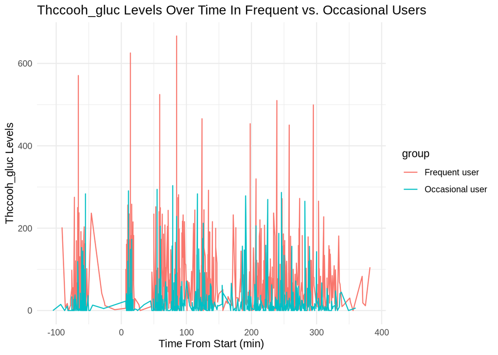

```r
options(repr.plot.width=12, repr.plot.height=8)

thccooh_gluc_data <- WB |>
  filter(!is.na(thccooh_gluc)) |>
  select(id, group, time_from_start, thccooh_gluc)


ggplot(thccooh_gluc_data, aes(x = time_from_start, y = thccooh_gluc, color = group)) +
  geom_line() +
  labs(title = 'Thccooh_gluc Levels Over Time In Frequent vs. Occasional Users',
       x = 'Time From Start (min)',
       y = 'Thccooh_gluc Levels') +
  theme_minimal()
```

**Result:** From the graph above, it can be seen that while both occasional and frequent users experience similar “spikes” and an overall trend in their levels of thccooh_gluc over time, the magnitude of the thccooh_gluc levels are overall much higher for frequent users than for occasional users.

Then we conducted a similar exploration of thc against time from start because we know that thc is one of the most important compounds in predicting whether someone recently used weed or not. Here we are visualizing it in Breath against different types of treatment.

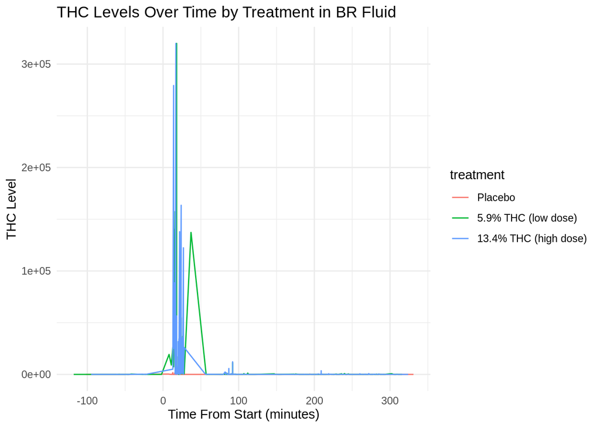

```r
ggplot(BR, aes(x = time_from_start, y = thc, color = treatment)) +
  geom_line() +
  theme_minimal() +
  labs(title = 'THC Levels Over Time by Treatment in BR Fluid',
       x = 'Time From Start (minutes)',
       y = 'THC Level')
```

**Result:** As we can see from the plot above, there is a surge of thc level in breath right after taking the drug, especially for high doses. However, the thc level also decreased more reapidly for high does compared to the low does condition.

Then we decided to compare the mean levels of the compounds thc, thccooh, thccooh_gluc, and thcoh between occasional and frequent users by treatment type to see if there are any significant differences in mean levels of the compounds in blood between frequent and infrequent users and to get a better idea if user frequency or treatment type is more influential on these levels.

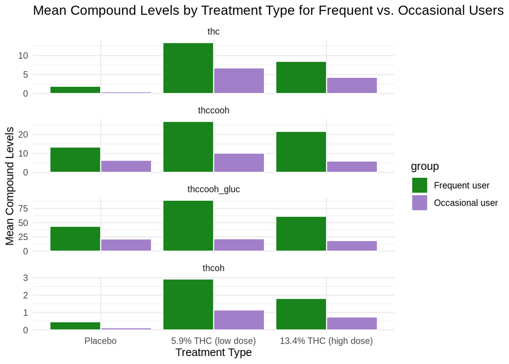

```r
thccooh_gluc_treatment_data <- WB |>
  filter(!is.na(thccooh_gluc) & !is.na(thc) & !is.na(thcoh) & !is.na(thccooh)) |>
  select(id, group, treatment, thccooh_gluc, thc, thcoh, thccooh)

thccooh_gluc_treatment_data_long <- thccooh_gluc_treatment_data |>
  pivot_longer(cols = c(thccooh_gluc, thc, thcoh, thccooh), names_to = "compound", values_to = "value")

ggplot(thccooh_gluc_treatment_data_long, aes(x = treatment, y = value, fill = group)) +
  geom_bar(stat = "summary", fun = "mean", position = "dodge", color = "white") +
  labs(title = 'Mean Compound Levels by Treatment Type for Frequent vs. Occasional Users',
       x = 'Treatment Type',
       y = 'Mean Compound Levels') +
  scale_fill_manual(values = c("#19831C", "#A27FC9")) +
  facet_wrap(~compound, scales = "free_y", ncol = 1) +
  theme_minimal()
```

**Result:** It can be seen from the plot above that regardless of compound and treatment type, frequent users always have higher mean levels of a compound than occasional users. Additionally, it can be seen that for both occasional and frequent users, across all compounds, they both follow a similar trend of having the lowest mean levels of a compound for the placebo, the highest for the low dose, and an in-between amount for the high dose.

Next, we also compared the compound level within the participants’ Oral Fluid at timepoint T2A, which is right after the participants takes the weed, at this time, each compound concentration should reach a max level.

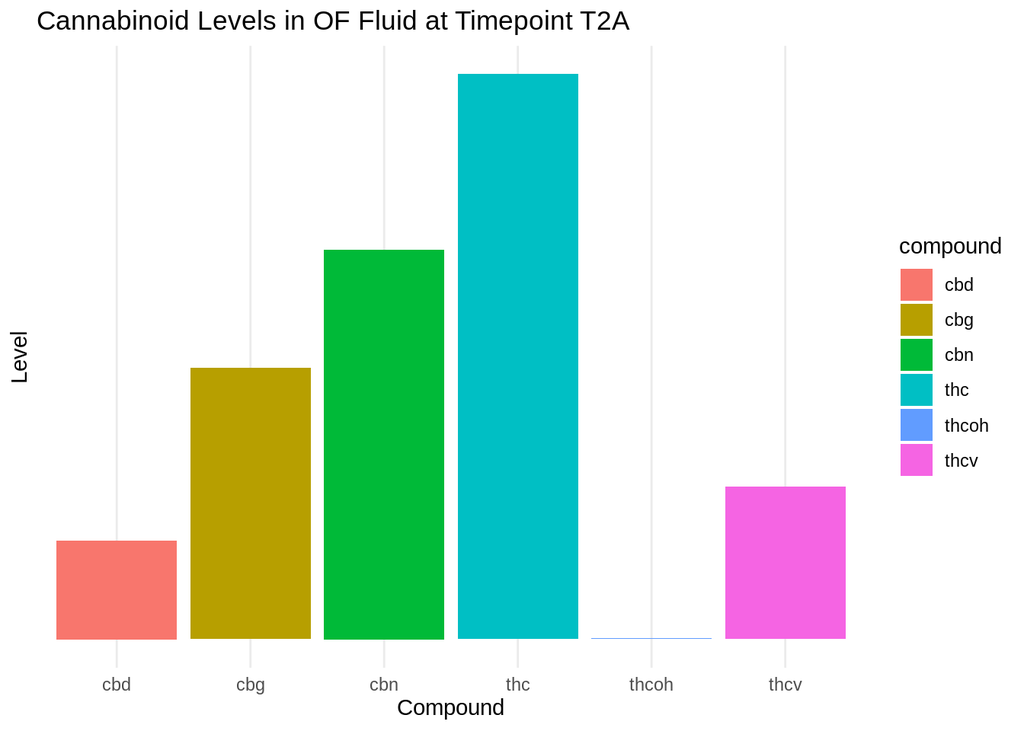

```r
#Visualization of Cannabinoid Profiles in OF Fluid
OF_specific_timepoint <- OF %>%
  filter(timepoint == "T2A") %>%
  select(cbn, cbd, thc, thcoh, cbg, thcv) %>%
  pivot_longer(cols = everything(), names_to = "compound", values_to = "level")

# Bar plot of cannabinoid levels at a specific timepoint in the OF dataset
ggplot(OF_specific_timepoint, aes(x = compound, y = level, fill = compound)) +
  geom_bar(stat = "identity") +
  scale_y_log10() +  #log scale y axis
  theme_minimal() +
  labs(title = 'Cannabinoid Levels in OF Fluid at Timepoint T2A',
       x = 'Compound',
       y = 'Level')
```

**Result:** From the plot above, we can see a super high concentration of thc followed by cbn and cbg, this can signify that these are the three compounds that reacted the most after a participant takes the drug.

Lastly, we investigated the concentration of THC in oral fluid samples of individuals after the use of cigarettes with varying THC doses. We categorized the subjects into two groups: “Frequent users” and “Occasional users.” Using boxplots faceted by treatment groups, we compared the THC concentrations across different timepoints.

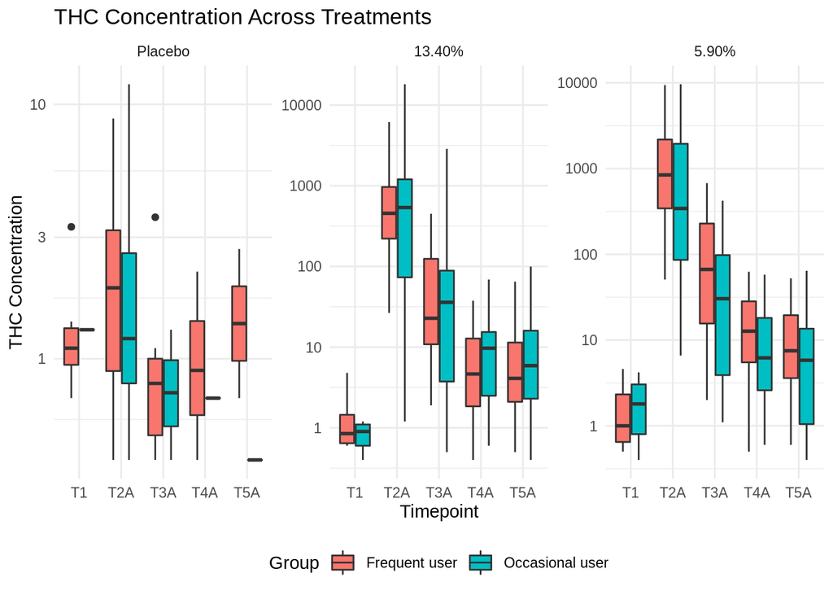

```r
OF %>%
  ggplot(aes(x = timepoint, y = thc, fill = group)) +
  geom_boxplot() +
  scale_y_log10() +  # log scale
  facet_wrap(~treatment, scales = 'free_y') +
  theme_minimal() +
  labs(title = "THC Concentration Across Treatments",
       x = "Timepoint",
       y = "THC Concentration",
       fill = "Group") +
  theme(legend.position = "bottom")
```

### Primary Question Analysis

Here, we will conduct our analysis to help answer our primary question - Which compound, in which matrix, and at what cutoff is the best biomarker of recent use?

To answer this question, we can dissect this question into three sub questions:

Below is also an explanation of why we chose the steps that we did for this analysis:

1. **Which matrix:** In order to figure out the most important matrix, we decided to use a random forest model because by leveraging a Random Forest model, we can scrutinize each dataset/matrix to assess predictive efficacy.

2. **Which compound:** In order to figure out which compound, we harnessed the model’s integral feature importance metrics because it would give us good insight into the most predictive compound.

3. **At what cutoff:** Finally, we employ ROC curve analyses on the paramount compounds within the optimal matrix, establishing precise cutoff values for the identification of recent use.

Following the **first step**, we can build and train the random forest model on all three datasets:

One thing to note here is that we defined recent use to be participants whose timepoint is not T1, and did not take a Placebo.

Random Forest - oral fluid:

```r
library(randomForest)
library(caret)

OF <- OF %>%
  mutate(recent_user = ifelse(timepoint != "T1" & treatment != "Placebo", 1, 0))

OF <- OF %>%
  select(-id, -treatment, -treatment_2, -timepoint, -time_from_start)

OF$recent_user <- as.factor(OF$recent_user)

OF <- na.omit(OF)

set.seed(123)

splitIndex <- createDataPartition(OF$recent_user, p = 0.8, list = FALSE, times = 1)

train_data <- OF[splitIndex, ]
test_data <- OF[-splitIndex, ]

rf_model <- randomForest(recent_user ~ ., data = train_data, importance = TRUE, na.action = na.omit)

predictions <- predict(rf_model, test_data)

accuracy <- sum(predictions == test_data$recent_user) / nrow(test_data)
print(accuracy)
```

```
## [1] 0.9180328
```

```r
importance_data <- data.frame(Variable = row.names(importance(rf_model)),
                              MeanDecreaseAccuracy = importance(rf_model)[, "MeanDecreaseAccuracy"])
importance_data <- importance_data[order(-importance_data$MeanDecreaseAccuracy), ]

print(importance_data)
```

```
##        Variable MeanDecreaseAccuracy
## thc         thc            64.672142
## cbn         cbn            27.464694
## cbg         cbg            16.858576
## cbd         cbd            15.854666
## thcv       thcv            11.749931
## thca_a   thca_a             9.778362
## group     group             6.419279
## thcoh     thcoh             2.675983
## fluid     fluid             0.000000
```

As seen from our results above, our Random Forest model actually predicted pretty well with an accuracy of 91.8%. Hence, from this we can see that the most important compounds in order of most significant to least significant are thc, cbn, cbg, cbd, thcv, thca_a, and thcoh.

Random Forest - whole blood:

```r
WB <- WB %>%
  mutate(recent_user = ifelse(timepoint != "T1" & treatment != "Placebo", 1, 0))

WB <- WB %>%
  select(-id, -treatment, -timepoint, -time_from_start)

WB$recent_user <- as.factor(WB$recent_user)

WB <- na.omit(WB)

set.seed(123)

splitIndex <- createDataPartition(WB$recent_user, p = 0.8, list = FALSE, times = 1)

train_data <- WB[splitIndex, ]
test_data <- WB[-splitIndex, ]

rf_model <- randomForest(recent_user ~ ., data = train_data, importance = TRUE, na.action = na.omit)

predictions <- predict(rf_model, test_data)

accuracy <- sum(predictions == test_data$recent_user) / nrow(test_data)
print(accuracy)
```

```
## [1] 0.7796053
```

```r
importance_data <- data.frame(Variable = row.names(importance(rf_model)),
                              MeanDecreaseAccuracy = importance(rf_model)[, "MeanDecreaseAccuracy"])
importance_data <- importance_data[order(-importance_data$MeanDecreaseAccuracy), ]

print(importance_data)
```

```
##                  Variable MeanDecreaseAccuracy
## thc                   thc            62.966705
## thccooh           thccooh            41.341754
## thccooh_gluc thccooh_gluc            37.357140
## thcoh               thcoh            29.662025
## group               group            29.379289
## cbn                   cbn            19.330906
## cbd                   cbd            15.620654
## cbg                   cbg             6.201264
## fluid_type     fluid_type             0.000000
## thcv                 thcv             0.000000
```

Random Forest - breath:

```r
BR <- BR %>%
  mutate(recent_user = ifelse(timepoint != "T1" & treatment != "Placebo", 1, 0))

BR <- BR %>%
  select(-id, -treatment, -timepoint, -time_from_start)

BR$recent_user <- as.factor(BR$recent_user)

BR <- na.omit(BR)

set.seed(123)

splitIndex <- createDataPartition(BR$recent_user, p = 0.8, list = FALSE, times = 1)

train_data <- BR[splitIndex, ]
test_data <- BR[-splitIndex, ]

rf_model <- randomForest(recent_user ~ ., data = train_data, importance = TRUE, na.action = na.omit)

predictions <- predict(rf_model, test_data)

accuracy <- sum(predictions == test_data$recent_user) / nrow(test_data)
print(accuracy)
```

```
## [1] 0.5925926
```

```r
importance_data <- data.frame(Variable = row.names(importance(rf_model)),
                              MeanDecreaseAccuracy = importance(rf_model)[, "MeanDecreaseAccuracy"])
importance_data <- importance_data[order(-importance_data$MeanDecreaseAccuracy), ]

print(importance_data)
```

```
##       Variable MeanDecreaseAccuracy
## thc        thc            35.292644
## fluid    fluid             0.000000
## group    group            -2.287272
```

After running the same model for the whole blood and breath datasets, we can see that the best matrix to use is Oral Fluid because we have a 91.8% accuracy in predicting compared to 77.9% with Blood and 59.3% with breath.

Also, the top 5 most important compounds in order of most important to least important are thc, cbn, cbg, cbd, thcv. Below from our ROC analysis section, we will determine the single most important compound.

Now we will use an ROC analysis to determine the single most important compound and the optimal cutoff for each of the compounds.

```r
library(pROC)
OF$thc <- as.numeric(as.character(OF$thc))
roc_obj <- roc(OF$recent_user, OF$thc)
optimal_cutoff <- coords(roc_obj, "best", ret="threshold")

print(optimal_cutoff)
```

```
##   threshold
## 1      1.35
```

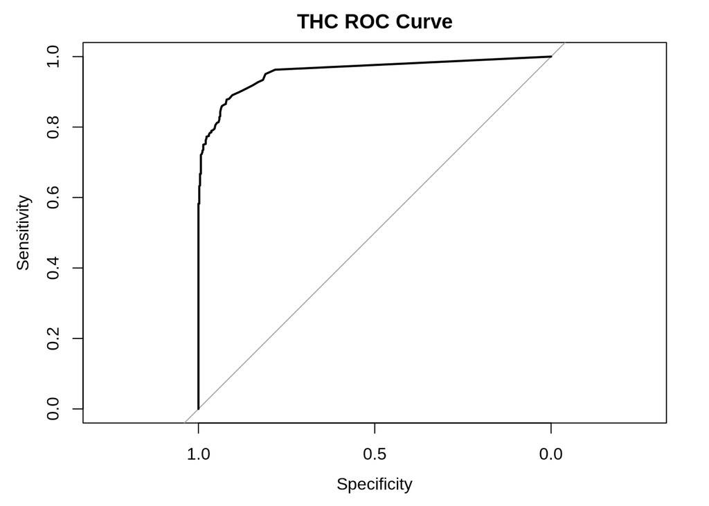

```r
plot(roc_obj, main="THC ROC Curve")
abline(v = optimal_cutoff, col = "red")
```

```r
OF$cbn <- as.numeric(as.character(OF$cbn))
roc_obj <- roc(OF$recent_user, OF$cbn)
optimal_cutoff <- coords(roc_obj, "best", ret="threshold")

print(optimal_cutoff)
```

```
##   threshold
## 1      0.45
```

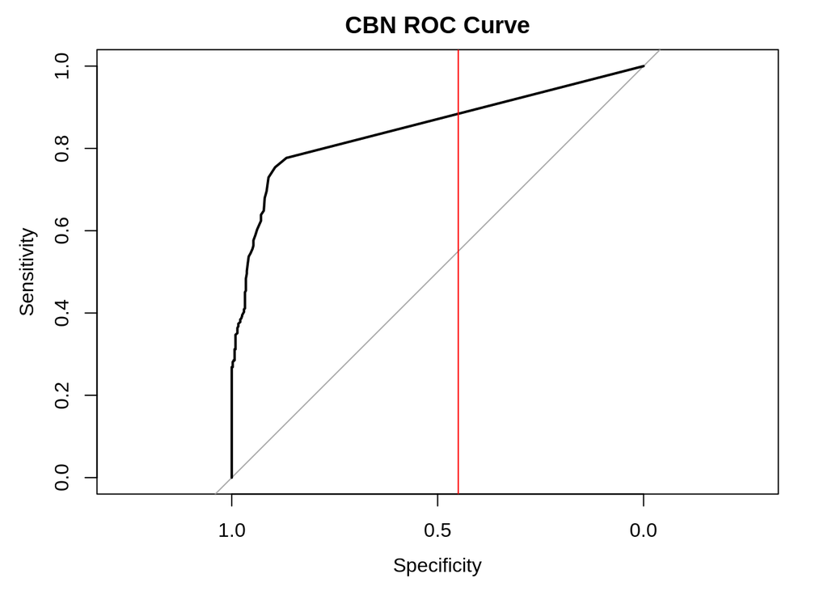

```r
plot(roc_obj, main="CBN ROC Curve")
abline(v = optimal_cutoff, col = "red")
```

```r
OF$cbg <- as.numeric(as.character(OF$cbg))
roc_obj <- roc(OF$recent_user, OF$cbg)
optimal_cutoff <- coords(roc_obj, "best", ret="threshold")

print(optimal_cutoff)
```

```
##   threshold
## 1       0.5
```

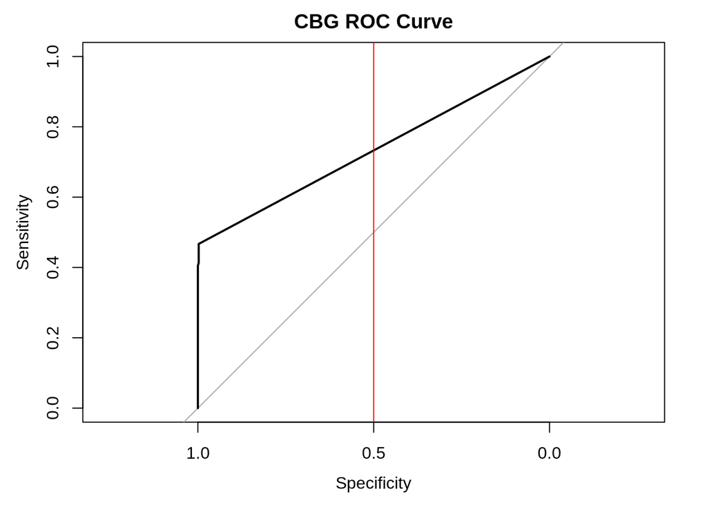

```r
plot(roc_obj, main="CBG ROC Curve")
abline(v = optimal_cutoff, col = "red")
```

```r
OF$cbd <- as.numeric(as.character(OF$cbd))
roc_obj <- roc(OF$recent_user, OF$cbd)
optimal_cutoff <- coords(roc_obj, "best", ret="threshold")

print(optimal_cutoff)
```

```
##   threshold
## 1       0.2
```

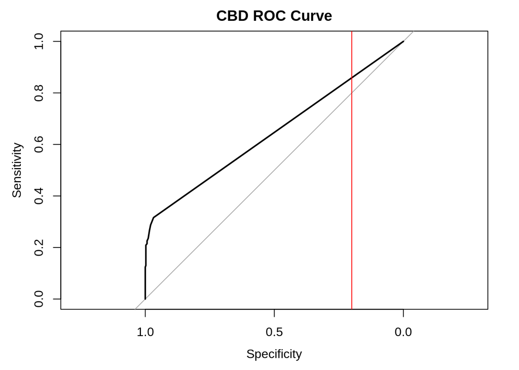

```r
plot(roc_obj, main="CBD ROC Curve")
abline(v = optimal_cutoff, col = "red")
```

```r
OF$thcv <- as.numeric(as.character(OF$thcv))
roc_obj <- roc(OF$recent_user, OF$thcv)
optimal_cutoff <- coords(roc_obj, "best", ret="threshold")

print(optimal_cutoff)
```

```
##   threshold
## 1       0.2
```

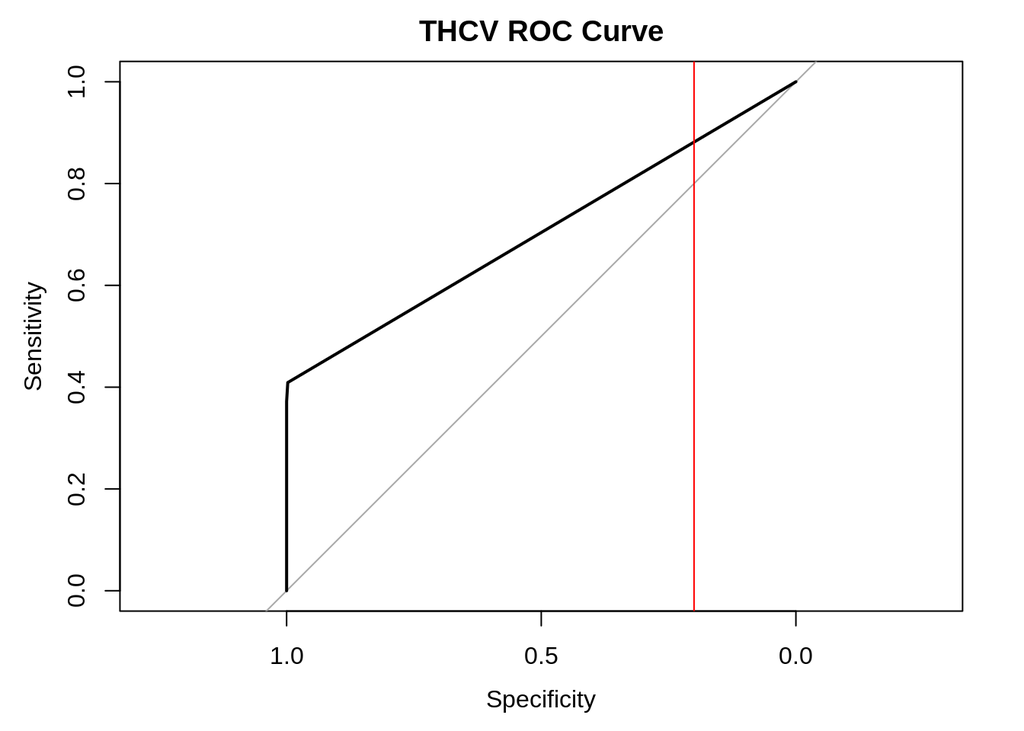

```r
plot(roc_obj, main="THCV ROC Curve")
abline(v = optimal_cutoff, col = "red")
```

The results from the ROC tests above shows that the optimal cutoff for the five different compounds are: thc (1.35), cbn (0.45), cbg (0.5), cbd (0.2), and thcv (0.2).

The ROC analysis yields a compelling insight, pinpointing **THC as the most reliable biomarker for recent use within the Oral Fluid matrix, with an optimal threshold of 1.35**. This conclusion is drawn from the ROC curve’s pronounced performance, characterized by its steep ascent and plateau, reflecting an exceptional balance between specificity and sensitivity. It’s this distinct curve profile that underscores THC’s capacity to differentiate recent use with high precision, thus affirming its status as the preeminent biomarker in this context.

### Secondary Question Analysis

Here, we will conduct our analysis to help answer our secondary question - How does the frequency of cannabis use correlate with the use of other hard drugs for people of ages 15-64?

#### The Data - Secondary Question

In order to address this question, we decided to find another data set that had information on people’s cannabis and other drug use (Kaggle, 2018).

The data can be seen here:

```r
drug_use_data = read_csv('data/secondary_q_data.csv')

drug_use_data
```

```
## # A tibble: 17 × 28
##    age       n `alcohol-use` `alcohol-frequen… `marijuana-use` `marijuana-frequ…
##    <chr> <dbl>         <dbl>             <dbl>           <dbl>             <dbl>
##  1 12     2798           3.9                 3             1.1                 4
##  2 13     2757           8.5                 6             3.4                15
##  3 14     2792          18.1                 5             8.7                24
##  4 15     2956          29.2                 6            14.5                25
##  5 16     3058          40.1                10            22.5                30
##  6 17     3038          49.3                13            28                  36
##  7 18     2469          58.7                24            33.7                52
##  8 19     2223          64.6                36            33.4                60
##  9 20     2271          69.7                48            34                  60
## 10 21     2354          83.2                52            33                  52
## 11 22-23  4707          84.2                52            28.4                52
## 12 24-25  4591          83.1                52            24.9                60
## 13 26-29  2628          80.7                52            20.8                52
## 14 30-34  2864          77.5                52            16.4                72
## 15 35-49  7391          75                  52            10.4                48
## 16 50-64  3923          67.2                52             7.3                52
## 17 65+    2448          49.3                52             1.2                36
## # … with 22 more variables: cocaine-use <dbl>, cocaine-frequency <chr>,
## #   crack-use <dbl>, crack-frequency <chr>, heroin-use <dbl>,
## #   heroin-frequency <chr>, hallucinogen-use <dbl>,
## #   hallucinogen-frequency <dbl>, inhalant-use <dbl>, inhalant-frequency <chr>,
## #   pain-releiver-use <dbl>, pain-releiver-frequency <dbl>,
## #   oxycontin-use <dbl>, oxycontin-frequency <chr>, tranquilizer-use <dbl>,
## #   tranquilizer-frequency <dbl>, stimulant-use <dbl>,
## #   stimulant-frequency <dbl>, meth-use <dbl>, meth-frequency <chr>,
## #   sedative-use <dbl>, sedative-frequency <dbl>
```

Explanation of variables -

age: age group of people in the dataset

n: number of people in that age group alcohol-use:

alcohol-frequency: Percentage of those in an age group who used alcohol in the past 12 months

alcohol-use: Median number of times a user in an age group used alcohol in the past 12 months

marijuana-use: Percentage of those in an age group who used marijuana in the past 12 months

marijuana-frequency: Median number of times a user in an age group used marijuana in the past 12 months

cocaine-use: Percentage of those in an age group who used cocaine in the past 12 months

cocaine-frequency: Median number of times a user in an age group used cocaine in the past 12 months

crack-use Percentage of those in an age group who used crack in the past 12 months

crack-frequency: Median number of times a user in an age group used crack in the past 12 months

heroin-use: Percentage of those in an age group who used heroin in the past 12 months

heroin-frequency: Median number of times a user in an age group used heroin in the past 12 months

hallucinogen-use: Percentage of those in an age group who used hallucinogens in the past 12 months

hallucinogen-frequency: Median number of times a user in an age group used hallucinogens in the past 12 months

inhalant-use: Percentage of those in an age group who used inhalants in the past 12 months

inhalant-frequency: Median number of times a user in an age group used inhalants in the past 12 months

pain-releiver-use: Percentage of those in an age group who used pain relievers in the past 12 months

pain-releiver-frequency: Median number of times a user in an age group used pain relievers in the past 12 months

oxycontin-use: Percentage of those in an age group who used oxycontin in the past 12 months

oxycontin-frequency: Median number of times a user in an age group used oxycontin in the past 12 months

tranquilizer-use: Percentage of those in an age group who used tranquilizer in the past 12 months

tranquilizer-frequency: Median number of times a user in an age group used tranquilizer in the past 12 months

stimulant-use: Percentage of those in an age group who used stimulants in the past 12 months

stimulant-frequency: Median number of times a user in an age group used stimulants in the past 12 months

meth-use: Percentage of those in an age group who used meth in the past 12 months

meth-frequency: Median number of times a user in an age group used meth in the past 12 months

sedative-use: Percentage of those in an age group who used sedatives in the past 12 months

sedative-frequency: Median number of times a user in an age group used sedatives in the past 12 months

For the purposes of our study, the variables we are choosing to focus on in addition to age and marijuana_frequency are cocaine_frequency and meth_frequency because according to the US Deapartment of Transportation, “Cocaine and methamphetamine can make drivers more aggressive and reckless” (US Department of Transportation, n.d.). Additionally, we are choosing to focus only on ages 15-64 since those are typical driving ages.

##### Data Preprocessing - Secondary Question

Here we will preprocess the data to make it easier to work with

First, we dropped the columns we didn’t need

Then, for any missing values, we replaced them with 0 because there were two missing values so we thought it would be a fair assumption to make that wouldn’t impact our analysis too much.

Our data after this preprocessing is displayed below

```r
# Dropping columns we don't need
needed_columns <- c("age", "n", "marijuana-frequency", "cocaine-frequency", "meth-frequency")
drug_use_data <- drug_use_data[, needed_columns]

# Replacing missing values with 0
drug_use_data[["cocaine-frequency"]] <- as.numeric(drug_use_data[["cocaine-frequency"]])
drug_use_data[["meth-frequency"]] <- as.numeric(drug_use_data[["meth-frequency"]])

drug_use_data[drug_use_data == "-"] <- 0

drug_use_data[is.na(drug_use_data)] <- 0

drug_use_data
```

```
## # A tibble: 17 × 5
##    age       n `marijuana-frequency` `cocaine-frequency` `meth-frequency`
##    <chr> <dbl>                 <dbl>               <dbl>            <dbl>
##  1 12     2798                     4                 5                0
##  2 13     2757                    15                 1                5
##  3 14     2792                    24                 5.5             24
##  4 15     2956                    25                 4               10.5
##  5 16     3058                    30                 7               36
##  6 17     3038                    36                 5               48
##  7 18     2469                    52                 5               12
##  8 19     2223                    60                 5.5            105
##  9 20     2271                    60                 8               12
## 10 21     2354                    52                 5                2
## 11 22-23  4707                    52                 5               46
## 12 24-25  4591                    60                 6               21
## 13 26-29  2628                    52                 5               30
## 14 30-34  2864                    72                 8               54
## 15 35-49  7391                    48                15              104
## 16 50-64  3923                    52                36               30
## 17 65+    2448                    36                 0                0
```

##### Exploratory Data Analysis - Secondary Question

Here, we are looking at the distribution of age groups in our data so that we can have an idea of how to factor this in when interpreting our results.

In order to do so, we decided to create a histogram of the age groups.

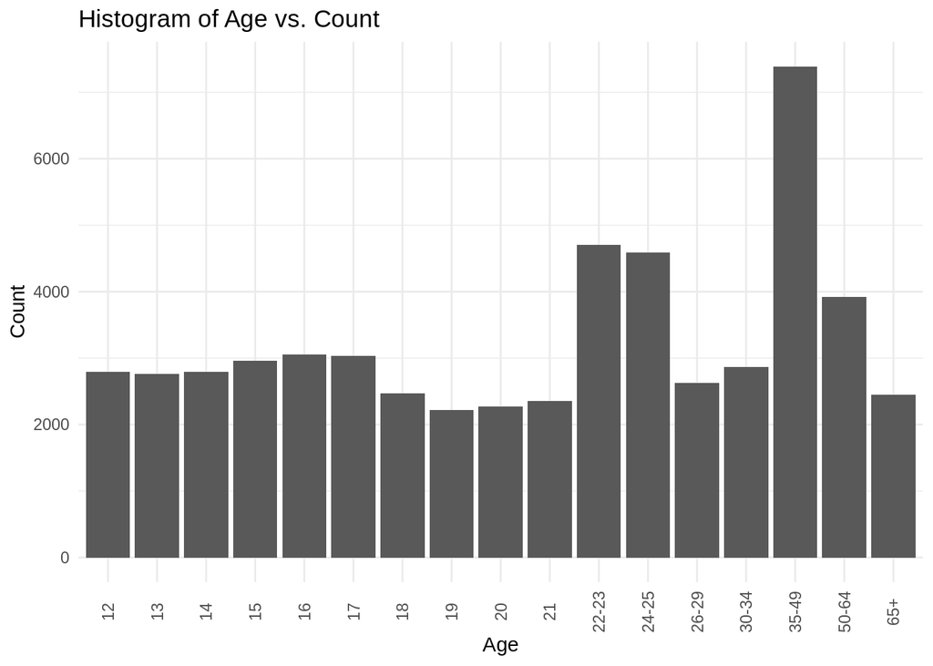

```r
drug_use_data <- drug_use_data %>%
  mutate(age = as.character(age)) %>%
  mutate(age = factor(age, levels = sort(unique(age))))

ggplot(drug_use_data, aes(x = age, y = n)) +
  geom_bar(stat = "identity") +
  theme_minimal() +
  labs(x = "Age", y = "Count", title = "Histogram of Age vs. Count") +
  theme(axis.text.x = element_text(angle = 90, vjust = 0.5))
```

From our histogram, we can see that the age groups are fairly uniformly distributed except for age groups 22-23, 24-25, and 34-49.

#### Analysis - Secondary Question

Here, we will conduct the analysis to answer the question -

How does the frequency of cannabis use correlate with the use of other hard drugs for people of ages 15-64?

In order to answer this question, we will create a linear regression model for people of ages 15-64 comparing the marijuana_frequency and the cocaine_frequency and a linear regression model for comparing the marijuana_frequency and the meth_frequency as shown below:

Marijuana_frequency vs. Cocaine_frequency:

```r
drug_use_data_driving_ages <- drug_use_data %>%
  filter(!age %in% c(12, 13, 14,"65+"))

drug_use_data_driving_ages <- drug_use_data_driving_ages %>%
  mutate(
    `marijuana-frequency` = as.numeric(as.character(`marijuana-frequency`)),
    `cocaine-frequency` = as.numeric(as.character(`cocaine-frequency`))
  )

# Fitting the linear regression for marijuana frequency as a function of cocaine frequency
model <- lm(`marijuana-frequency` ~ `cocaine-frequency`, data = drug_use_data_driving_ages)

# Viewing the summary of the model to see the results
summary(model)
```

```
##
## Call:
## lm(formula = `marijuana-frequency` ~ `cocaine-frequency`, data = drug_use_data_driving_ages)
##
## Residuals:
##     Min      1Q  Median      3Q     Max
## -24.358  -3.003   2.493  10.044  22.044
##
## Coefficients:
##                     Estimate Std. Error t value Pr(>|t|)
## (Intercept)          48.7589     5.4631   8.925 2.27e-06 ***
## `cocaine-frequency`   0.1496     0.4513   0.332    0.746
## ---
## Signif. codes:  0 '***' 0.001 '**' 0.01 '*' 0.05 '.' 0.1 ' ' 1
##
## Residual standard error: 13.51 on 11 degrees of freedom
## Multiple R-squared:  0.009897,   Adjusted R-squared:  -0.08011
## F-statistic:  0.11 on 1 and 11 DF,  p-value: 0.7464
```

From the results, we can see that the linear regression analysis indicates that there is not a statistically significant linear relationship between marijuana frequency and cocaine frequency. There is a a light positive relationship between marijuana frequency and cocaine frequency as indicated by the slope value 0.1496, but it is not significant because the p-value associated with the cocaine-frequency coefficient (p = 0.746) is much higher than the conventional threshold of 0.05. Consequently, we fail to reject the null hypothesis that there is no linear relationship between these two variables.

The Multiple R-squared value of 0.009897 shows that only about 0.99% of the variability in marijuana frequency can be explained by cocaine frequency which is not much.

In summary, the linear regression analysis does not provide evidence of a significant linear relationship between marijuana frequency and cocaine frequency based on the given sample. Hence, there may not be too much combined use of marijuana and cocaine.

Marijuana_frequency vs. Meth_frequency:

```r
drug_use_data_driving_ages <- drug_use_data %>%
  filter(!age %in% c(12, 13, 14,"65+"))

drug_use_data_driving_ages <- drug_use_data_driving_ages %>%
  mutate(
    `marijuana-frequency` = as.numeric(as.character(`marijuana-frequency`)),
    `meth-frequency` = as.numeric(as.character(`meth-frequency`))
  )

# Fitting the linear regression for marijuana frequency as a function of meth frequency
model <- lm(`marijuana-frequency` ~ `meth-frequency`, data = drug_use_data_driving_ages)

# Viewing the summary of the model to see the results
summary(model)
```

```
##
## Call:
## lm(formula = `marijuana-frequency` ~ `meth-frequency`, data = drug_use_data_driving_ages)
##
## Residuals:
##     Min      1Q  Median      3Q     Max
## -23.082  -6.565   2.566   5.365  20.902
##
## Coefficients:
##                  Estimate Std. Error t value Pr(>|t|)
## (Intercept)      47.35398    5.90238   8.023 6.36e-06 ***
## `meth-frequency`  0.06934    0.11694   0.593    0.565
## ---
## Signif. codes:  0 '***' 0.001 '**' 0.01 '*' 0.05 '.' 0.1 ' ' 1
##
## Residual standard error: 13.37 on 11 degrees of freedom
## Multiple R-squared:  0.03097,    Adjusted R-squared:  -0.05712
## F-statistic: 0.3516 on 1 and 11 DF,  p-value: 0.5652
```

From the results, we can see that the linear regression analysis indicates that there is not a statistically significant linear relationship between marijuana frequency and meth frequency. There is a a light positive relationship between marijuana frequency and meth frequency as indicated by the slope value 0.06934, but it is not significant because the p-value associated with the cocaine-frequency coefficient (p = 0.565) is much higher than the conventional threshold of 0.05. Consequently, we fail to reject the null hypothesis that there is no linear relationship between these two variables.

The Multiple R-squared value of 0.03097 shows that only about 3% of the variability in marijuana frequency can be explained by meth frequency which is not much.

## Results and Discussion

Overall, as seen from our graphs, models, and the interpretations of them above, we were able to address our two questions fairly accurately.

For our first question - Which compound, in which matrix, and at what cutoff is the best biomarker of recent use, we analyzed the question piece-by-piece - “which compound”, “which matrix”, and “what cutoff”. In order to determine “which compound”, we used a random forest model for our blood, oral fluid, and breath datasets and found that the best matrix was oral fluid because we found a 91.8% accuracy with it compared to 77.9% with Blood and 59.3% with breath. In order to determine “what compound”, we also looked at the results of our random forest models and found that the top 5 most important compounds in order of most important to least important were thc, cbn, cbg, cbd, thcv. Lastly, for “which cutoff”, we created ROC curves for each compound and found that the optimal cutoff for the five different compounds were thc (1.35), cbn (0.45), cbg (0.5), cbd (0.2), and thcv (0.2) so from this we determined 1.35 as the optimal cutoff. Combining these results together we determined that using THC with an oral fluid test with a cutoff level of 1.35 would be the best biomarker for recent use

For our second question - How does the frequency of cannabis use correlate with the use of other hard drugs for people of ages 15-64, we created 2 linear regression models comparing marijuana_frequency vs. cocaine_frequnecy and marijuana_frequency vs. meth_frequency to determine if there is a high correlation between using marijuana and those two other drugs. From our results and looking at the slope values, p-values, and R^2 values, we found that for both cocaine and meth, there was no significant correlation between the two indicating that it is not likely that people who use marijuana are also likely to use cocaine and meth.

### Conclusion

In conclusion, our study provides new insights for cannabis-related driving laws. Our main motivation of this study was to ensure that people stay safe on the road while also not wrongly incriminating individuals. From prior research, we found that the most effective way to determine if someone is actually impaired on the road is by determining if they used cannabis recently. Thus, we conducted analysis in order to determine what chemical compound, at what cutoff, using what test would help officers determine if someone is actually impaired or not and we found that if an individual has THC levels above 1.35 using an oral fluid test, it is likely that they used cannabis recently and is thus impaired. Furthermore, we decided to extend our investigation by looking at if there is a correlation between marijuana use and other hard-drug use (specifically cocaine and meth) for people within a driving age range (15-64) since by understanding the co-occurrence of cannabis use with other hard drugs, law enforcement can better prioritize testing procedures, ensuring a more focused approach in identifying potential substance-related impairments. For this question, we concluded that it is not likely that people who use marijuana are also likely to use cocaine and meth. However, we believe that investigating this question again with more data and with further analysis would help to solidy this conclusion. Overall, this study can help inform future driving laws and help improve drug testing methods especially with even further analysis in the future and can help keep people safe on the road while minimizing discrimination against drug users.

### Sources

Arkell, T., Spindle, T., Kevin, R., Vandrey, R., & McGregor, I. (2020). The failings of per se limits to detect cannabis-induced driving … National Library of Medicine. https://www.tandfonline.com/doi/full/10.1080/15389588.2020.1851685

Bergamaschi, M., Karschner, E., Goodwin, R., Scheidweiler, K., Hirvonen, J., Queiroz, R., & Huestis, M. (2013). Impact of Prolonged Cannabinoid Excretion in Chronic Daily Cannabis Smokers’ Blood on Per Se Drugged Driving Laws . Academic.oup.com. https://academic.oup.com/clinchem/article/59/3/519/5622035?login=false

Department of Cannabis Control - State of California. (2023). California’s cannabis laws. Department of Cannabis Control. https://cannabis.ca.gov/cannabis-laws/laws-and-regulations/#:~:text=California%20became%20the%20first%20state,and%20adult%20(recreational)%20use.

Drug-impaired driving. NHTSA. (n.d.). https://www.nhtsa.gov/risky-driving/drug-impaired-driving#:~:text=Alcohol%2C%20marijuana%2C%20and%20other%20drugs,drivers%20more%20aggressive%20and%20reckless.

Ellis, S. (2023). Cogs 137 - 11-CS01-data - GitHub Pages. Cogs 137 Github. https://cogs137.github.io/website/content/lectures/11-cs01-data-slides.html

Hubbard, J., Hoffman, M., Ellis, S., Sobolesky, P., Smith, B., Suhandynata, R., Sones, E., Sanford, S., Umlauf, A., Huestis, M., Grelloti, D., Grant, I., Marcotte, T., & Fitzgerald, R. (2021). Biomarkers of Recent Cannabis Use in Blood, Oral Fluid and Breath. Academic.oup.com. https://academic.oup.com/jat/article/45/8/820/6311388?login=false#303593274

Kaggle. (2018). drug-use-by-age. GitHub. https://github.com/fivethirtyeight/data/blob/master/drug-use-by-age/drug-use-by-age.csv

Report State Medical Cannabis Laws. National Conference of State Legislatures. (2023). https://www.ncsl.org/health/state-medical-cannabis-laws

Section 9: Alcohol and drugs. California DMV. (2023, February 1). https://www.dmv.ca.gov/portal/handbook/california-driver-handbook/alcohol-and-drugs/#:~:text=Blood%20Alcohol%20Concentration%20(BAC)%20Limits&text=It%20is%20illegal%20for%20you,are%20under%2021%20years%20old.

U.S. Department of Health and Human Services. (2022, August 22). Marijuana and hallucinogen use among young adults reached all-time high in 2021. National Institutes of Health. https://www.nih.gov/news-events/news-releases/marijuana-hallucinogen-use-among-young-adults-reached-all-time-high-2021